Problema de Programmación lineal Reading List Kelly Raas 24 June 2019

# Formulación del Problema

El objetivo de este pequeño projecto es crear una lista de lecturas que nos permita leer el máximo númer de libros al año posible, dado un tiempo limitado que podemos destinar a la lectura y dado un presupuesto limitado para gastar en los libros. Además la lista debe contener una cierta cantidad de libros de unos determinados géneros. Para ello haremos uso de la programación lineal y comparamos los resultados del caso crisp con el caso difuso.

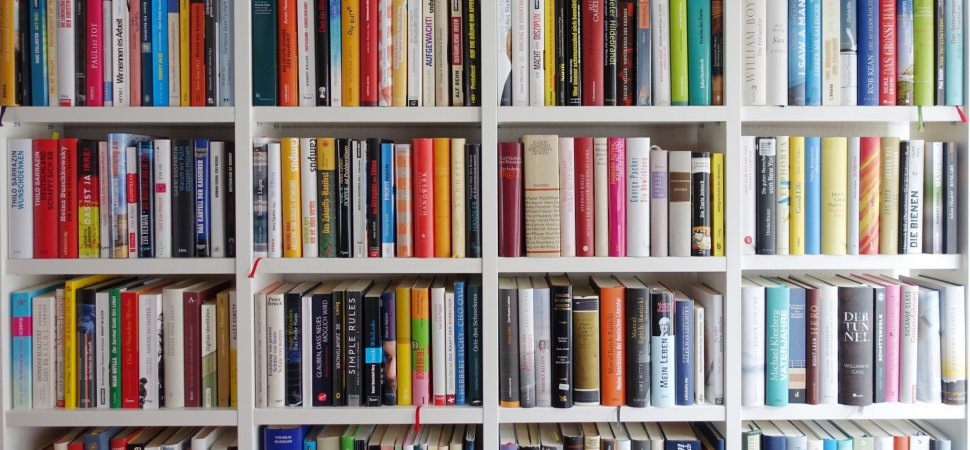

## Preparación del problema

Para este problema trabajamos con una lista de 50 libros recomendados por amazon para los temas “Data Science”, “Personal Development” y “Historic fiction novels”. Los datos vienen en una tabla con 4 variables:

- el titulo
- el número de páginas
- el precio
- el género

Primero cargamos los datos.

```r
booklist = read.xls("amazon-book-list.xls")
head(booklist)
```

```
                                                                           Title
1                                         The Hundred-Page Machine Learning Book
2                         Malware Data Science: Attack Detection and Attribution
3           Data Smart: Using Data Science to Transform Information into Insight
4 The Data Science Handbook: Advice and Insights from 25 Amazing Data Scientists
5             The Model Thinker: What You Need to Know to Make Data Work for You
6    Predictive Analytics: The Power to Predict Who Will Click, Buy, Lie, or Die
  Pages Price Genre
1   159 29.14    DS
2   272 28.65    DS
3   432 25.65    DS
4   346 24.99    DS
5   448 20.69    DS
6   368 16.32    DS
```

# Problema de Optimización (caso crisp)

## Función objetiva:

Qeremos maximizar la cantidad de libros a leer en un año.

$$\begin{equation} \begin{aligned}
\textrm{max} && \sum_{i=1}^{n} book_i &&& book_i \in \{0,1\} \; \forall \; i \in 1,...,50 \\ \\
\end{aligned} \end{equation}$$

## Restricciones:

Las restricciones vienen dados por:

### 1. El tiempo que estimamos que podamos destinar a la lectura de los libros

$$\begin{equation} \begin{aligned}
\sum_{i=1}^{n} pages_i*book_i \leq 9360 \\
\end{aligned} \end{equation}$$

### 2. Presupuesto para gastar en libros.

Queremos gastar como máximo 200€ en libros en este año.

$$\begin{equation} \begin{aligned}
\sum_{i=1}^{n} price_i*book_i \leq 200 \\
\end{aligned} \end{equation}$$

### 3. Género de los libros

Queremos que la lista contega como mínimo 3 libros de cada género, pero como máximo 5 de “Personal development”

$$\begin{equation} \begin{aligned}
&&& \sum books_{DS} \geq 3 \\
&&& \sum books_{HF} \geq 3 \\
&&& \sum books_{PD} \geq 3 \\
&&& \sum books_{PD} \leq 5 \\
\end{aligned} \end{equation}$$

## Método Simplex

El problema de optimización queda de la siguiente forma:

$$\begin{equation} \begin{aligned}
\left\{ \begin{array}{l}
& \textrm{max} && \sum_{i=1}^{n} book_i \\
& \textrm{s.a.} && \sum_{i=1}^{n} price_i*book_i \leq 200 \\
&&& \sum_{i=1}^{n} pages_i*book_i \leq 9360 \\
&&& \sum books_{DS} \geq 3 \\
&&& \sum books_{HF} \geq 3 \\
&&& \sum books_{PD} \geq 3 \\
&&& \sum books_{PD} \leq 5 \\
&&& book_i \in \{0,1\} \; \forall \; i \in 1,...,50 \\
\end{array}\right.
\end{aligned} \end{equation}$$

Preparamos los datos para la fórmula:

```r
pages = as.vector(booklist$Pages)
price = as.vector(booklist$Price)
DS = ifelse(booklist$Genre == "DS",1,0)
PD = ifelse(booklist$Genre == "PD",1,0)
HF = ifelse(booklist$Genre == "HF",1,0)
```

Definimos la función objetiva `f.obj`, la matrix de restricciones `f.con`, la dirección de los restricciones `f.dir` y el vector de valores para el lado derecho de las restricciones `f.rhs`.

```r
f.obj = rep(1,50)
f.con = matrix(c(pages, price, DS, HF, PD, PD), nrow = 6, byrow= TRUE)
f.dir = c("<=", "<=", ">=", ">=", ">=", "<=")
f.rhs = c(9360, 200, 3, 3, 3, 5)
```

Resolvemos el problema.

```r
solution = lp("max", f.obj, f.con, f.dir, f.rhs, binary.vec=1:50)
solution
```

```
Success: the objective function is 18
```

El resultado son **18 libros**. Veamos la lista.

```
 [1] "Practical Statistics for Data Scientists: 50 Essential Concepts"
 [2] "The Master Algorithm: How the Quest for the Ultimate Learning Machine Will Remake Our World"
 [3] "Life 3.0: Being Human in the Age of Artificial Intelligence"
 [4] "The 7 Habits of Highly Effective People: Powerful Lessons in Personal Change (Englisch)"
 [5] "Make Your Bed: Little Things That Can Change Your Life...And Maybe the World"
 [6] "You Are a Badass\xae: How to Stop Doubting Your Greatness and Start Living an Awesome Life"
 [7] "The Alchemist"
 [8] "Goodbye, Things: The New Japanese Minimalism"
 [9] "Before We Were Yours: A Novel"
[10] "The Alice Network: A Novel"
[11] "What the Wind Knows"
[12] "The Nightingale: A Novel"
[13] "The Lost Girls of Paris: A Novel"
[14] "Sold on a Monday: A Novel"
[15] "Beneath a Scarlet Sky"
[16] "Song of the Spirits"
[17] "Toward the Sea of Freedom"
[18] "Winter of the World: Book Two of the Century Trilogy"
```

Número total de páginas: 7730  
Gasto: 199.87€  
Los géneros se distribuyen de la siguiente manera:  
Data Sience: 3  
Personal Development: 5  
Novelas: 10